# data 시각화

### boxplot

사분위수 quantile를 함께 표시  
사분위수는 지나치게 범주에서 벗어나는 값들을 제외하고  
핵심적인 범주의 데이터만 범위로 지정할 수 있는 방법

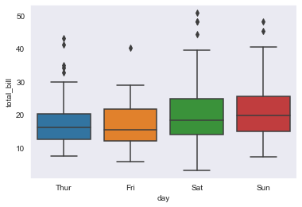

```python
import seaborn as sns

sns.set_style('dark')
sns.boxplot(x='day',y='total_bill', data=tips)
```

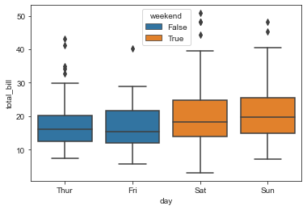

```python
import seaborn as sns
import matplotlib as mpl
import matplotlib.pyplot as plt
%matplotlib inline

sns.set_style(style='ticks',rc={"xtick.major.size": 8, "ytick.major.size": 8})
tips = sns.load_dataset("tips")

tips["weekend"] = tips["day"].isin(["Sat", "Sun"])
ax = sns.boxplot(x="day", y="total_bill", hue="weekend",
                 data=tips,dodge=False)
plt.show()
```

### clustermap

clustering이 된 heatmap  
단계간 엮어서 가장 유사도가 높은 데이터 쌍끼리 묶어 올라간다.  
데이터 분류 및 특징 도출이 가능하다.

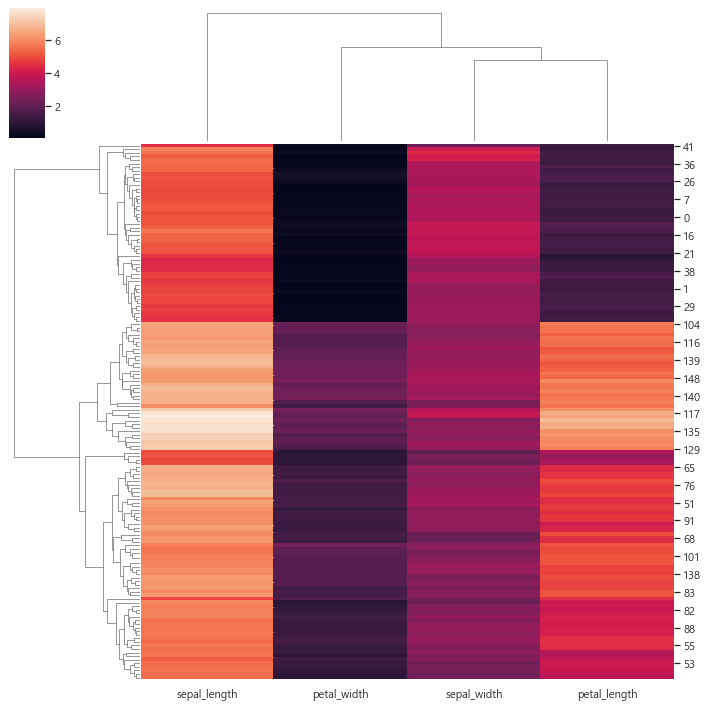

```python
import seaborn as sns
import matplotlib.pyplot as plt

sns.set(style="whitegrid", rc={'font.family':'malgun gothic'}, font_scale=1)
iris = sns.load_dataset("iris")
species = iris.pop("species")
g = sns.clustermap(iris)
```

### regplot

scatter plot과 line plot을 함께 볼 수 있는 plot

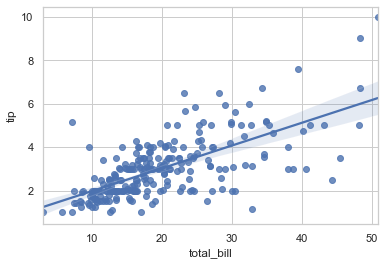

```python
import seaborn as sns

plt.rc("font", size=9, family="sans-serif")

tips = sns.load_dataset("tips")
ax = sns.regplot(x="total_bill", y="tip", data=tips)
```

### lmplot

regplot + facegrid를 합친 것으로 regplot을 여러개 보고싶을 때

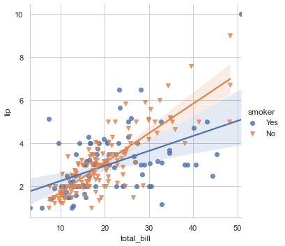

```python
import seaborn as sns
import matplotlib.pyplot as plt
import matplotlib.font_manager

plt.rc("font", size=9, family="sans-serif")

sns.lmplot(x='total_bill',y='tip', data=tips, hue='smoker', markers=['o','v'])
plt.show()
```

[figure not shown]

```python
import matplotlib.pyplot as plt
import matplotlib.font_manager as fm

plt.rc('font',size=2,family='malgun gothic')
fm._rebuild()
sns.lmplot( x = 'total_bill', y = 'tip', data = tips, hue = 'sex', palette = 'seismic' )

plt.show()
```